# Assigment1

Pavel Linder, Nikita Brancatisano

11/6/2019

## Installing packages

```
## Package 'GA' version 3.2
```

## What does it mean for a function to be non-convex?

A function is non-convex (or concave) if it is a continuous function whose value at the midpoint of every interval in its domain does not exceed the arithmetic mean of its values at the ends of the interval.

# Task 1: Maximization of a non-convex function.

# 1. Code a method f(x, y) that computes a value z, given an input tuple (x, y).

```r
f <- function(x, y)  {
  z <- ((1 - x)^2) + (exp(1) * (y - (x^2))^2)
}
```

# 2. Code a method that visualizes the Rosenbrock function in 3D

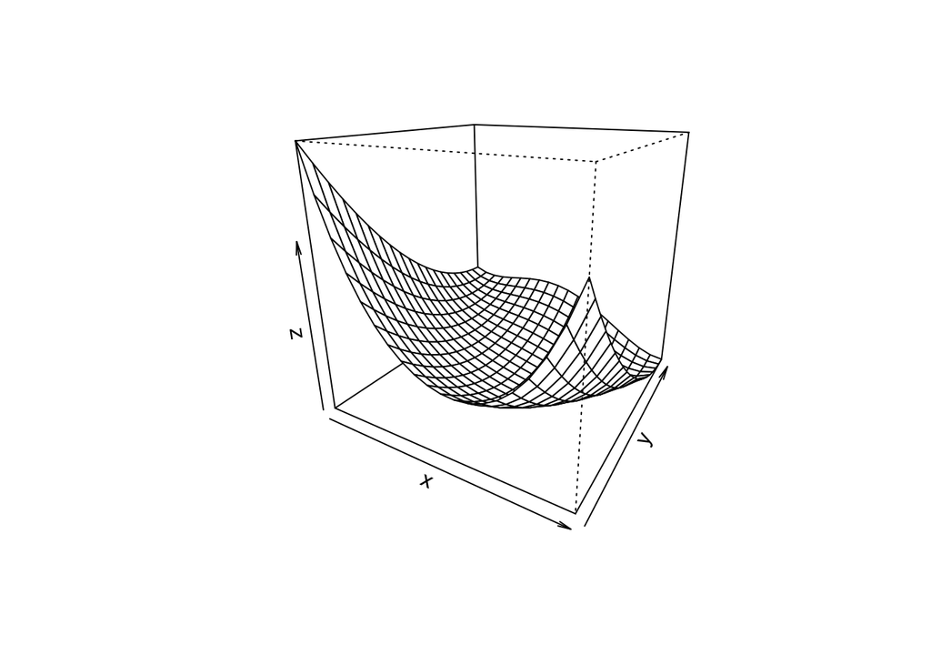

```r
x <- y <- seq(-1, 1, length= 20)
z <- outer(x, y, f)
z[is.na(z)] <- 1 # change non-defined elements to 1
persp(x, y, z, theta = 30, phi = 20)
```

# 3. Code a genetic algorithm, that attempts to find the global maximum of this function.

Here, we tried several crossover method and then selected the best one.

```r
#We select a list of crossovers
crossovers = c("ga_spCrossover",
              "gabin_spCrossover", "gabin_uCrossover",
              "gareal_spCrossover", "gareal_waCrossover", "gareal_laCrossover", "gareal_blxCrossover", "gareal_laplaceCrossover",
              "gaperm_cxCrossover", "gaperm_pmxCrossover", "gaperm_pmxCrossover"
        )
```

[output not shown]

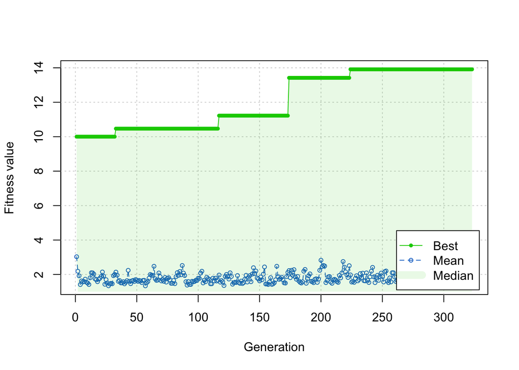

```r
solution = results[idx]
plot(GA)
```

```r
summary(GA)
```

```
## ── Genetic Algorithm ───────────────────
##
## GA settings:
## Type                  =  real-valued
## Population size       =  50
## Number of generations =  1000
## Elitism               =  2
## Crossover probability =  0.8
## Mutation probability  =  0.1
## Search domain =
##       x1 x2
## lower -1 -1
## upper  1  1
##
## GA results:
## Iterations             = 323
## Fitness function value = 13.91175
## Solution =
##              x1        x2
## [1,] -0.9708444 -0.978117
```

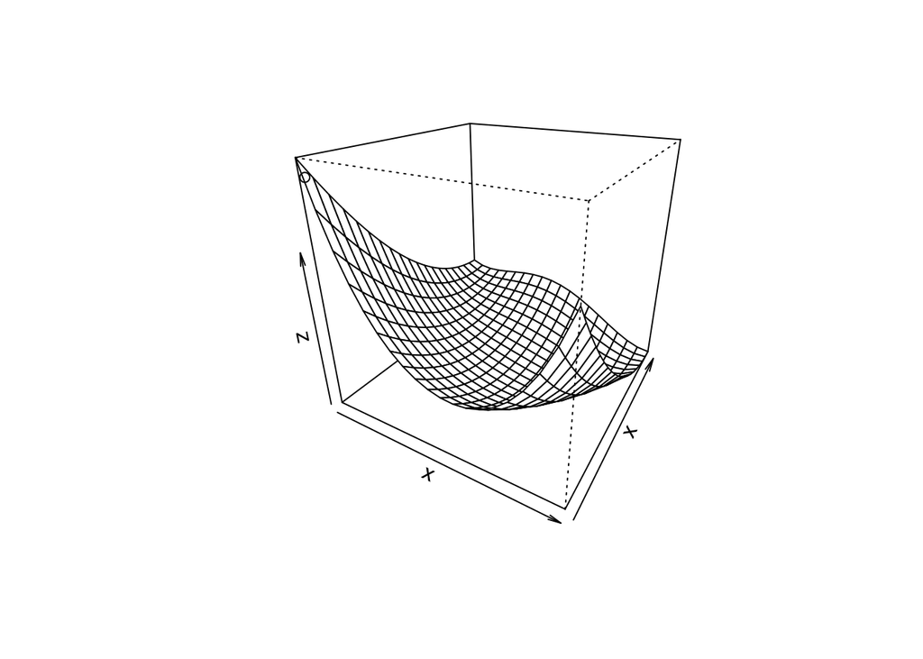

```r
max_x = as.vector(GA@solution[,1])
max_y = as.vector(GA@solution[,2])
max_z = as.vector(f(GA@solution[,1], GA@solution[,2]))
{res <- persp(x = x, y = x, z = z,theta = 30, phi = 25)
points(trans3d(max_x, max_y, max_z, pmat=res))}
```

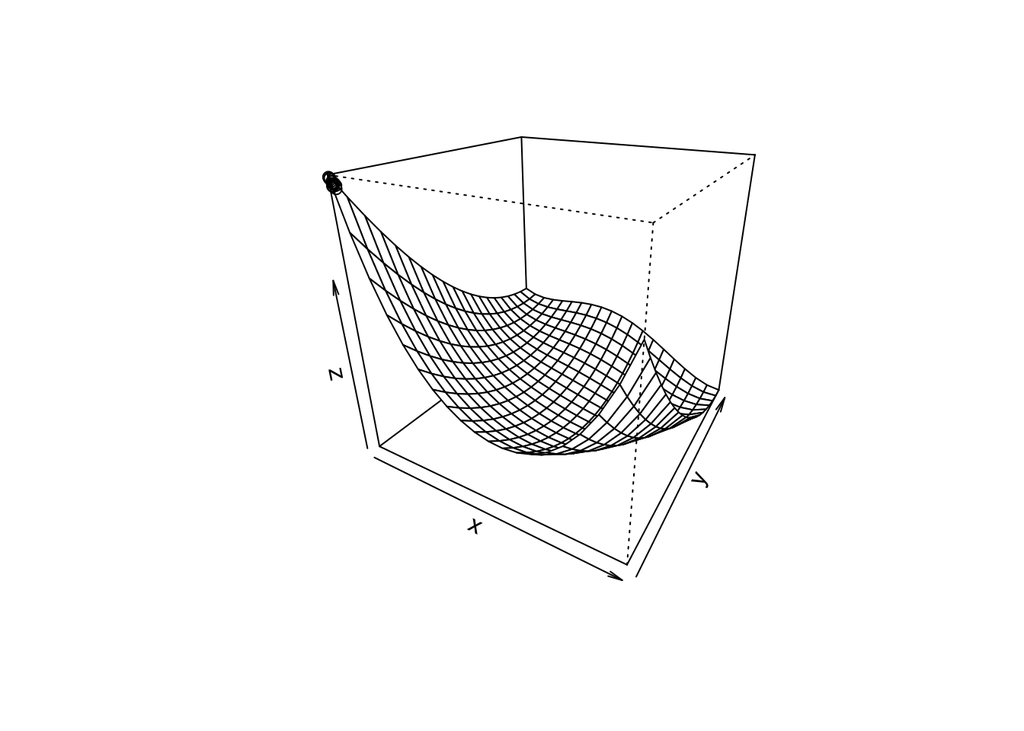

```r
# BONUS: Plot the trace of evolution
history_x = c()
history_y = c()

for (i in 1:12) {
    GA2 <- ga(type = "real-valued",
              fitness =  function(x) f(x[1], x[2]),
              lower = c(-1, -1), upper = c(1, 1),
              popSize = 50, maxiter = 50*i, run = 100)
    history_x[i] <- GA2@solution[,1]
    history_y[i] <- GA2@solution[,2]

}

{res2 <- persp(x=x, y = y, z = z,theta = 30, phi = 25)
points(trans3d(x = history_x, y =history_y , z = f(history_x, history_y), pmat = res))
}
```

## 4. Discuss the results. # How does performance vary when you are increasing the number of iterations? The performance is slowed down because the GA reaches the maximum solution before we run all of the iterations, thus increasing the number would only slow down the search without providing any significant benefit.

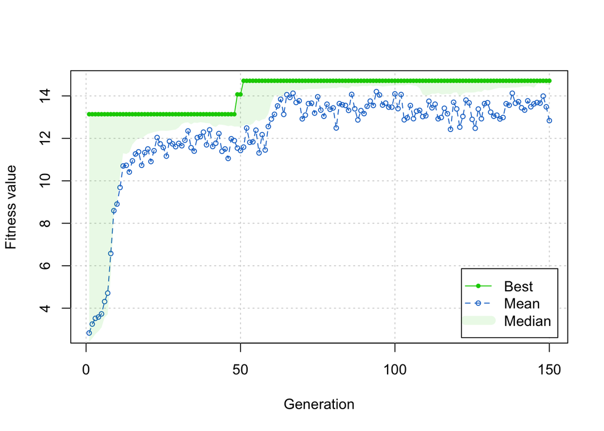

```r
plot(GA2)
```

# What about population size?

```r
time = c()
size = c()
```

[output not shown]

[output cut: 94 more lines]

[output not shown]

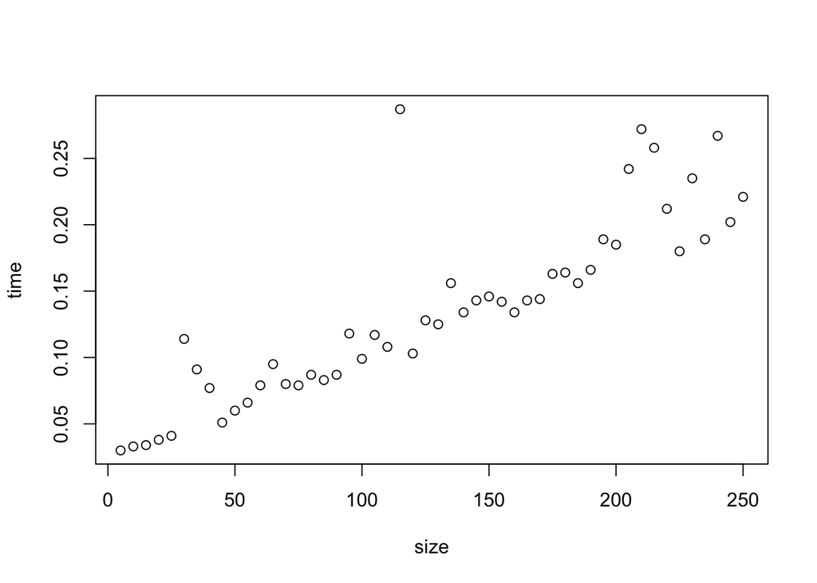

```r
plot(size, time)
```

# Explain the difference between local and global maxima. A local maxima is the biggest element for one given subset of the whole function. There can still be other values greater than this one, outside ofthe range of the subset. The global maximum is the largest overall value of the function.

## Task 2: Genetic feature selection

# 1) Read in the dataset

# 2) Split the data into training and test sets

```r
splited <- createDataPartition(
  y = target,
  p = .8,
  list = FALSE
)

learn = genes[ splited, ]
test = genes[-splited, ]

learn$X <- NULL
test$X <- NULL
```

# 3) Build a model using the training set

```r
ctrl <- trainControl(number = 3,
                     method = "repeatedcv")

PLSModel <- train(
  class ~ .,
  data = learn,
  method = "pls",
  preProc = c("center", "scale"),
  trControl = ctrl,
  tuneLenght = 1000
)



RFModel <- train(
  class ~ .,
  data = learn,
  method = "rf",
  preProc = c("center", "scale"),
  trControl = ctrl,
  tuneLenght = 1000
)



xgbModel <- train(
  class ~ .,
  data = learn,
  method = "xgbDART",
  preProc = c("center", "scale"),
  trControl = ctrl,
  tuneLenght = 100
)


SVMModel <- train(
  class ~ .,
  data = learn,
  method = "svmRadial",
  preProc = c("center", "scale"),
  trControl = ctrl,
  tuneLenght = 1000
)

models_compare <- resamples(list(RF=RFModel, XGBDART=xgbModel, PLS=PLSModel, SVM=SVMModel))

summary(models_compare)
```

```
##
## Call:
## summary.resamples(object = models_compare)
##
## Models: RF, XGBDART, PLS, SVM
## Number of resamples: 3
##
## Accuracy
##              Min.   1st Qu.    Median      Mean   3rd Qu.      Max. NA's
## RF      0.8095238 0.8138528 0.8181818 0.8592352 0.8840909 0.9500000    0
## XGBDART 0.9523810 0.9523810 0.9523810 0.9682540 0.9761905 1.0000000    0
## PLS     0.8181818 0.8590909 0.9000000 0.9060606 0.9500000 1.0000000    0
## SVM     0.7142857 0.7380952 0.7619048 0.7460317 0.7619048 0.7619048    0
##
## Kappa
##              Min.   1st Qu.    Median      Mean   3rd Qu.  Max. NA's
## RF      0.3913043 0.4061785 0.4210526 0.5624523 0.6480263 0.875    0
## XGBDART 0.8590604 0.8739746 0.8888889 0.9159831 0.9444444 1.000    0
## PLS     0.4883721 0.5903399 0.6923077 0.7268933 0.8461538 1.000    0
## SVM     0.0000000 0.0000000 0.0000000 0.0000000 0.0000000 0.000    0
```

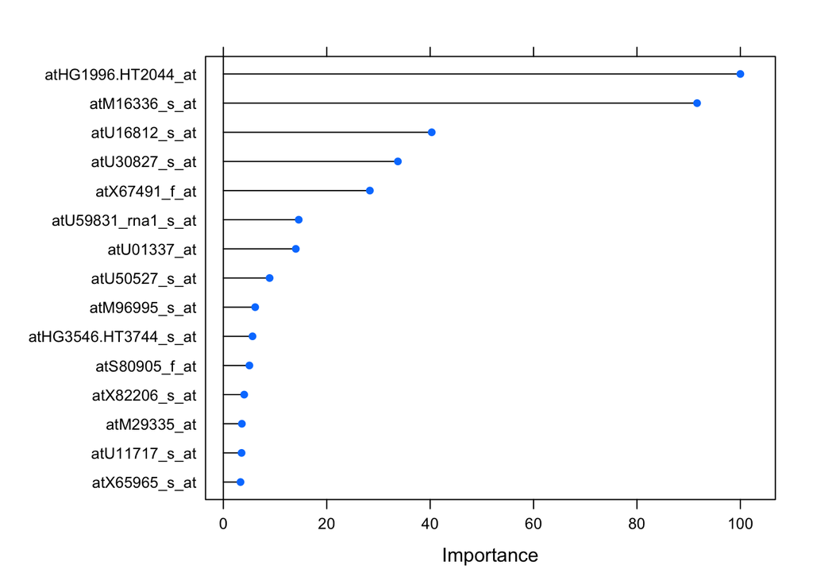

```r
varimp <- varImp(RFModel)
imp <- varimp$importance

plot(varimp, top = 15)
```

# 4) Evaluate the model using the test set

```r
plsClasses <- predict(xgbModel, newdata = test)
str(plsClasses)
```

```
##  Factor w/ 2 levels "DLBCL","FL": 1 1 1 2 1 1 1 1 1 1 ...
```

```r
plsProbs <- predict(xgbModel, newdata = test, type = "prob")
head(plsProbs)
```

|  | DLBCL | FL |
| --- | --- | --- |
| 1 | 0.9799632 | 0.02003676 |
| 2 | 0.9546090 | 0.04539102 |
| 3 | 0.9000072 | 0.09999281 |
| 4 | 0.4675853 | 0.53241467 |
| 5 | 0.9651281 | 0.03487188 |
| 6 | 0.9873404 | 0.01265961 |

```r
confusionMatrix(data = plsClasses, test$class)
```

```
## Confusion Matrix and Statistics
##
##           Reference
## Prediction DLBCL FL
##      DLBCL     9  0
##      FL        2  3
##
##                Accuracy : 0.8571
##                  95% CI : (0.5719, 0.9822)
##     No Information Rate : 0.7857
##     P-Value [Acc > NIR] : 0.3960
##
##                   Kappa : 0.6585
##
##  Mcnemar's Test P-Value : 0.4795
##
##             Sensitivity : 0.8182
##             Specificity : 1.0000
##          Pos Pred Value : 1.0000
##          Neg Pred Value : 0.6000
##              Prevalence : 0.7857
##          Detection Rate : 0.6429
##    Detection Prevalence : 0.6429
##       Balanced Accuracy : 0.9091
##
##        'Positive' Class : DLBCL
##
```

# Was the feature selection successful? Report how many features were needed for the final performance. Plot the trace of evolution and comment on the change of fitness through generations.

From the plot we can see that the accuracy within the subsets with more than 30 features is not increasing anymore.

```r
control <- rfeControl(functions = rfFuncs,
                   method = "repeatedcv",
                   number = 3,
                   verbose = FALSE)
outcomeName <- 'class'
predictors <- names(learn)[!names(learn) %in% outcomeName]
results <- rfe(learn[,predictors], learn[,outcomeName], rfeControl=control,
               sizes = c(1, 2, 4, 6, 8, 12, 16, 20, 32, 64, 128, 256, 512, 1000))
results
```

```
##
## Recursive feature selection
##
## Outer resampling method: Cross-Validated (3 fold, repeated 1 times)
##
## Resampling performance over subset size:
##
##  Variables Accuracy  Kappa AccuracySD KappaSD Selected
##          1   0.6851 0.2044   0.083474 0.16025
##          2   0.7312 0.2863   0.043213 0.11101
##          4   0.8266 0.5329   0.046812 0.12262
##          6   0.8903 0.7025   0.051838 0.14226        *
##          8   0.8569 0.5835   0.006821 0.08681
##         12   0.8728 0.6369   0.028508 0.12285
##         16   0.8903 0.6906   0.051838 0.14737
##         20   0.8895 0.6891   0.022496 0.05015
##         32   0.8895 0.6891   0.022496 0.05015
##         64   0.8736 0.6356   0.023098 0.05758
##        128   0.8895 0.6891   0.022496 0.05015
##        256   0.8411 0.5225   0.028144 0.06195
##        512   0.8266 0.4342   0.046812 0.18492
##       1000   0.7956 0.3410   0.062537 0.18930
##       1071   0.7956 0.3025   0.062537 0.18565
##
## The top 5 variables (out of 6):
##    atHG1996.HT2044_at, atU16812_s_at, atX67491_f_at, atX13810_s_at, atU01337_at
```

```r
predictors(results)
```

```
## [1] "atHG1996.HT2044_at" "atU16812_s_at"      "atX67491_f_at"
## [4] "atX13810_s_at"      "atU01337_at"        "atM16336_s_at"
```

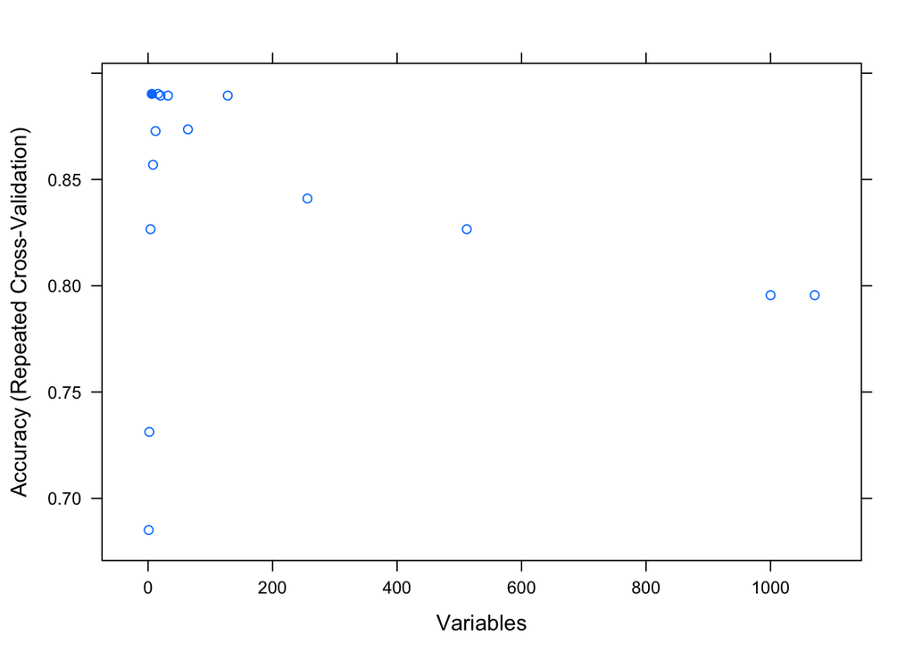

```r
plot(results)
```

# Suggest how to improve the selection process. We could use variables thar have a high influence of the class instead of selecting random ones

# The procedure might overfit the data set. How would you prevent it?

We would just run different tests with different ammounts of features and test cases and then we would test the results to see which quantity is actually the best one

# What are some of the key properties of the fitness function?

The fitness function represent the number of successes while testing our classifier. The more successes we have the more our function fits the model

# Compare the final result (set of features) with the same number of features, that correlate the most with the target variable

```r
result <- genes[, predictors(results)]

topCor <- data.frame(imp)
topCor$Vars <- row.names(topCor)
topCor <- topCor[order(-topCor$Overall),][1:20,]$Vars
cors <- genes[, topCor]

correlation <- head(round(cor(result, cors),2))
correlation
```

```
##                    atHG1996.HT2044_at atM16336_s_at atU16812_s_at
## atHG1996.HT2044_at               1.00          0.65         -0.14
## atU16812_s_at                   -0.14         -0.10          1.00
## atX67491_f_at                    0.18          0.39         -0.09
## atX13810_s_at                    0.30          0.15         -0.42
## atU01337_at                      0.13          0.15         -0.40
## atM16336_s_at                    0.65          1.00         -0.10
##                    atU30827_s_at atX67491_f_at atU59831_rna1_s_at
## atHG1996.HT2044_at          0.73          0.18               0.59
## atU16812_s_at               0.02         -0.09               0.05
## atX67491_f_at               0.30          1.00               0.40
## atX13810_s_at               0.24          0.07               0.07
## atU01337_at                 0.14          0.16               0.08
## atM16336_s_at               0.69          0.39               0.67
##                    atU01337_at atU50527_s_at atM96995_s_at
## atHG1996.HT2044_at        0.13          0.11          0.44
## atU16812_s_at            -0.40          0.40          0.07
## atX67491_f_at             0.16          0.09          0.07
## atX13810_s_at             0.56         -0.33         -0.25
## atU01337_at               1.00         -0.21         -0.12
## atM16336_s_at             0.15          0.27          0.39
##                    atHG3546.HT3744_s_at atS80905_f_at atX82206_s_at
## atHG1996.HT2044_at                -0.19         -0.32          0.23
## atU16812_s_at                      0.48          0.37          0.19
## atX67491_f_at                     -0.24          0.18          0.12
## atX13810_s_at                     -0.03          0.03         -0.44
## atU01337_at                       -0.06          0.01         -0.19
## atM16336_s_at                     -0.26         -0.06          0.33
##                    atM29335_at atU11717_s_at atX65965_s_at atX13810_s_at
## atHG1996.HT2044_at        0.07          0.56          0.19          0.30
## atU16812_s_at             0.30          0.17         -0.14         -0.42
## atX67491_f_at             0.24         -0.04          0.14          0.07
## atX13810_s_at             0.21          0.07          0.00          1.00
## atU01337_at               0.12          0.04          0.24          0.56
## atM16336_s_at             0.27          0.31          0.23          0.15
##                    atS82297_at atU09820_s_at atU14187_at atM31776_s_at
## atHG1996.HT2044_at       -0.12         -0.18        0.80          0.51
## atU16812_s_at             0.21          0.63       -0.04          0.12
## atX67491_f_at            -0.24         -0.23        0.18          0.27
## atX13810_s_at             0.02          0.10        0.28          0.10
## atU01337_at              -0.21         -0.07        0.11         -0.03
## atM16336_s_at            -0.27         -0.16        0.52          0.46
```

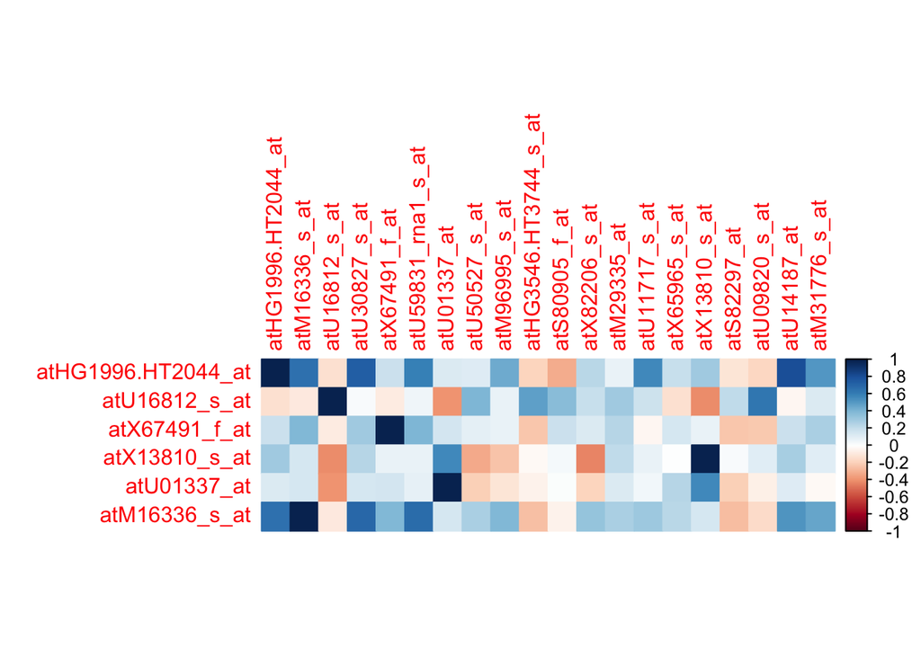

```r
corrplot(correlation, method="color")
```